# Bioinformatics, an introduction

25/11/2021

## **Bioinformatics and the central dogma of life**

[figure not shown]

## **Biological Databases**

Information from DNA, messenger RNA and protein are all found in biological databases. Biological databases can be broadly classified into:

**Sequences databases** -Nucleic acid and protein sequences are stored in sequence databases and structure databases store solved structures of RNA and proteins.

**Structure databases** - a database that is modeled around the various experimentally determined protein structures

**Functional databases**- Functional databases provide information on the physiological role of gene products, for example enzyme activities, mutant phenotypes, or biological pathways.

## **How do we get protein and gene sequences?**

Sequencing - Determine the order of nucleotide bases AGTC which can be translated to provide more information about proteins

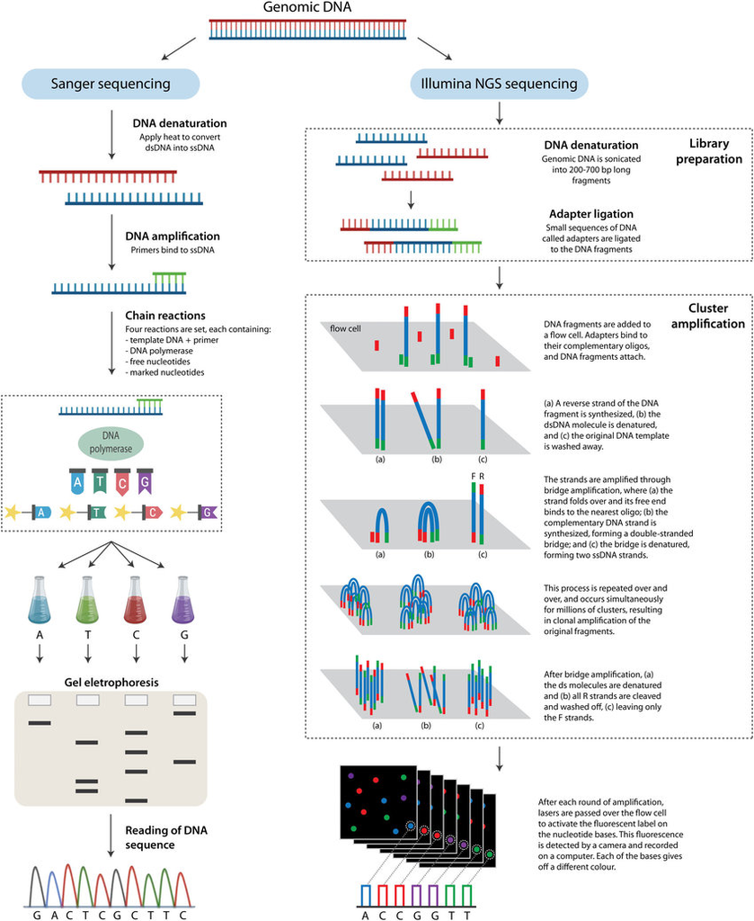

## **Sequence Databases**

Common sequence database include

*Nucleotide databases* The large databases: Genbank (US), Embl (Europe), DDBJ (Japan).

Genomic databases: Human (GDB), mouse (MGB), yeast (SGB)

Nucleotides present: AGTC (DNA)

*Protein Databases*

Swiss prot

Information from Databases readily updataed and easily found on

NCBI- National Center for Biotechnology Information (https://www.ncbi.nlm.nih.gov/)

Databases may provide information about gene functions, position in chromosome, lineage etc

**Exercise 1 Searching for Genes in Genbank Databases**

1. Go to Gene Bank https://www.ncbi.nlm.nih.gov/genbank/
2. Search for the hemoglobin subunit gamma 1 gene
3. Read the summary of the gene. State when the gene is expressed. Which gene replaces it in the adult stages.
4. Check the tissue expression of the gene. In which tissue is it highly expressed?
5. On which chromosome is it located?
6. How many exons does it have?

**Exercise 2 Searching for a protein in a Database**

1. Go to UniProt https://www.uniprot.org/
2. Search for the SPike glycoprotein S2 P0DTC2
3. What is the length of the Spike protein?
4. What is the function of the protein?
5. What is its subcellular location?
6. Under family and domains, state the various regions associated with the protein.
7. Go to sequences, click on the Fasta button to download the file. (It will be used later). Copy the entire sequence in your notepad.
8. Check the mutagenesis section. It provides information about gene mutations in the spike protein. What do you think is the effect of such mutations to the development of vaccines?

### **Searching Databases**

Information in biological databases searched and accessed through data retrieval systems. This system scan available databases and return an output. For instance, Entrez retrieval system searches for integrates information from various databases.

Searches are carried out by specific algorithms (set of rules/instructions). One common algorithm is Basic Local Alignment Search Tool (BLAST).

Sequences are normally searched against a database by directly aligning (arranging the sequences of DNA, RNA, or protein to identify regions of similarity that may be a consequence of functional, structural, or evolutionary relationships between the sequences)

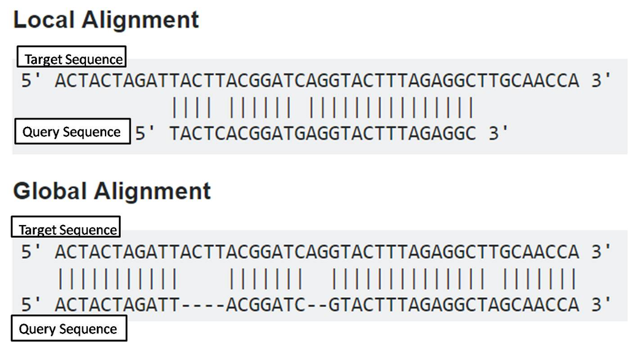

**Exercise 3 Use of Blast**

1. Go to NCBI
2. Select Blast
3. Check the various Blast flavours and state their functions
4. Select Protein Blast
5. Upload the sequences we saved into the query option.
6. Check the algorithm part. Ensure it is BlastP
7. Run Blast
8. Check the description, E-value, Query cover and Accession Number? The sequences belongs to?
9. Click on the accession number
10. What is the number BCN86353.1. How many amino acids are present in the sequence?. Are they similar to the previously identified sequence?
11. On the right hand side of the output, click on the conserved domains. Identify the super family, individual domains, and their functions.

**Exercise 4, Use of Blast with an Unknown sequence**

Below is the amino acid sequence of a protein associated with some bacterial cell envelopes. Use a protein BLAST (BLASTP) search to obtain information about it, and answer the questions below. MKLKNTLGVVIGSLVAASAMNAFAQGQNSVEIEAFGKRYFTDSVRNMKNADLYGGSIGYFLTD DVELALSYGEYHDVRGTYETGNKKVHGNLTSLDAIYHFGTPGVGLRPYVSAGLAHQNITNINSD SQGRQQMTMANIGAGLKYYFTENFFAKASLDGQYGLEKRDNGHQGEWMAGLGVGFNFGGSK AAPAPEPVADVCSDSDNDGVCDNVDKCPDTPANVTVDANGCPAVAEVVRVQLDVKFDFDKSK VKENSYADIKNLADFMKQYPSTSTTVEGHTDSVGTDAYNQKLSERRANAVRDVLVNEYGVEGG RVNAVGYGESRPVADNATAEGRAINRRVEAEVEAEAK

1. From what organism did it come?
2. What is the BLAST % query cover, E value and % Max Identity for the top hit?
3. What is the function of this kind of protein?
4. Based on what this protein does and where it is found, do you think this organism is a Gram positive or Gram negative bacterium? Explain your logic